# Classification Tree

Abhishek Kumar

3/14/2021

# Decision Tree

*Decision tree is a type of supervised learning algorithm (having a predefined target variable) that is mostly used in classification problems. It works for both categorical and continuous input and output variables. In this technique, we split the population or sample into two or more homogeneous sets (or sub-populations) based on most significant splitter / differentiator in input variables.*

**Setting Working Directory**

```r
path = "G:\\My Drive\\spring_semester\\statistical_ml\\section5"
setwd(path)
```

> rpart() function in the rpart package of ra can be used to perform the classification trees.

```r
library(rpart)
library(partykit) # Provides nicer plotting capabilities to represent trees.
```

**Function to plot classification tree**

```r
tree_plot = function(ct, ...){

  plot(ct, margin = 0.1)
  text(ct, use.n = TRUE, # add labels
     col = "darkorange2")
  plot(as.party(ct), ...)

}
```

```r
set.seed(127799)
n1 = 30
n2 = 30
x = c( rnorm(n1, -0.8, 1.2), rnorm(n2, 2.8, 1.2) )
y = factor( rep(0:1, c(n1, n2)) )

# fitting and plotting of classification tree

ct = rpart(y ~x)
ct
```

```
## n= 60
##
## node), split, n, loss, yval, (yprob)
##       * denotes terminal node
##
## 1) root 60 30 0 (0.50000000 0.50000000)
##   2) x< 1.213293 31  2 0 (0.93548387 0.06451613) *
##   3) x>=1.213293 29  1 1 (0.03448276 0.96551724) *
```

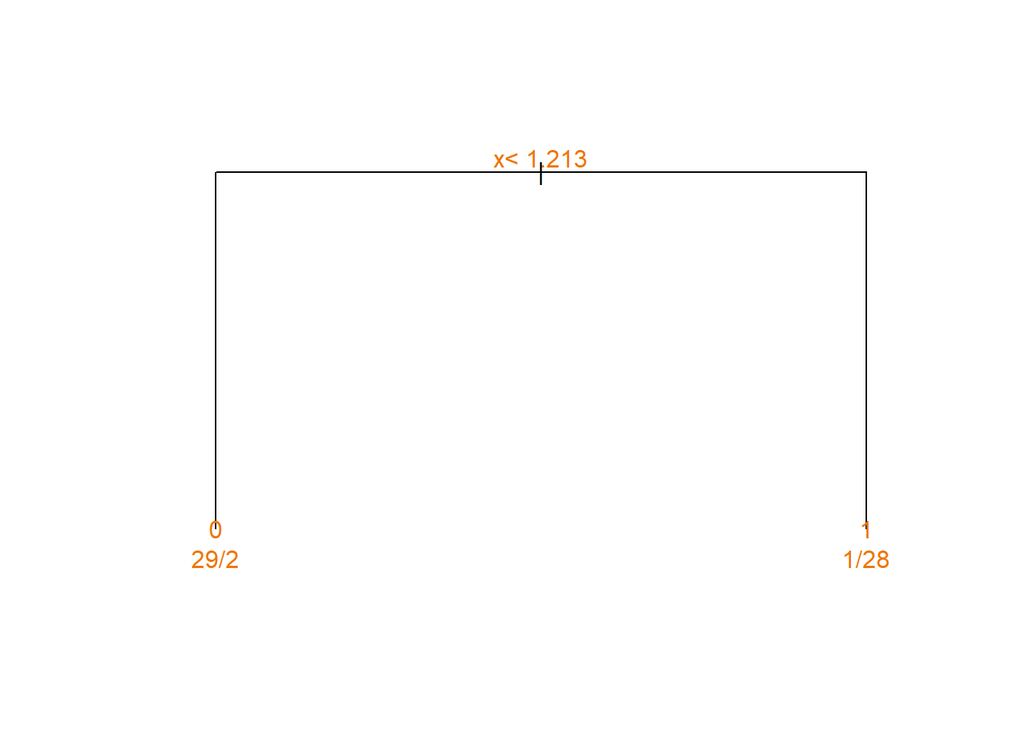

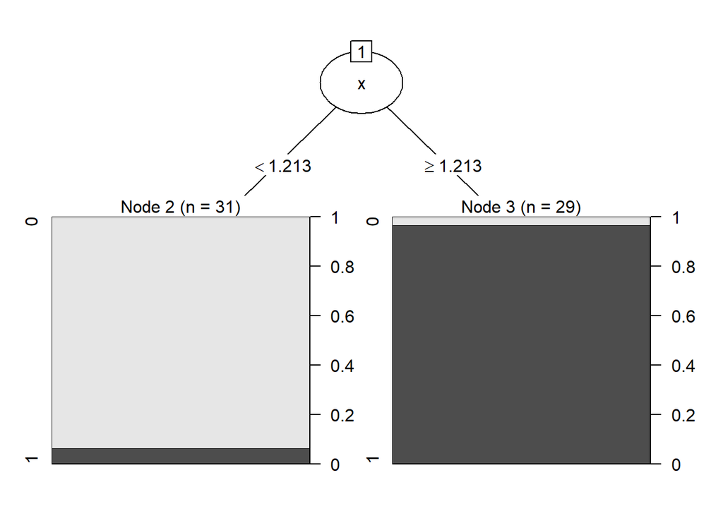

```r
tree_plot(ct)
```

*In the output we get:* > I used the classification tree to observe the classiffication of input variable x into classes of y belonging to 0 and 1. > The optimal split, the value of x. So in this the value of tau is 1.21 > Then we get the classification over the two different splits. > We also obtain the probability of observing a certain outcome of target variable y 1. For example, for x<1.21, there is a very high probability (0.93) of observing an observation wit y = 0. 2. Whereas in the other direction of the split, i.e for x>= 1.21, there is larger probability(0.96) of observing an outcome with y = 1.

*Plotting*

> Same can be observed from the plots which shows that for x < 1.21, 29 observations belonged to class 0 and 2 belonged to class 1, whereas for the x>= 1.21 28 values were observed in class 1 and only 1 in class 0. So it can be said from the observation that if we observe an input x with values less that 1.21 then it very likely that these observations belong to class 0 whereas observations having input x >= 1.21 has higher probability of belonging to class of 1.

```r
# generating simulated data

set.seed(894471) # To reproduce the example
n1 = 15
n2 = 15
n3 = 30

x = c( rnorm(n1, -0.8, 0.9), rnorm(n2, 5.5, 0.9), rnorm(n3, 2.8, 0.8))
y = factor( rep(0:1, c(n1+n2, n3)))

ct = rpart(y ~ x)
ct
```

```
## n= 60
##
## node), split, n, loss, yval, (yprob)
##       * denotes terminal node
##
## 1) root 60 30 0 (0.50000000 0.50000000)
##   2) x>=4.435236 14  0 0 (1.00000000 0.00000000) *
##   3) x< 4.435236 46 16 1 (0.34782609 0.65217391)
##     6) x< 0.5885832 13  0 0 (1.00000000 0.00000000) *
##     7) x>=0.5885832 33  3 1 (0.09090909 0.90909091) *
```

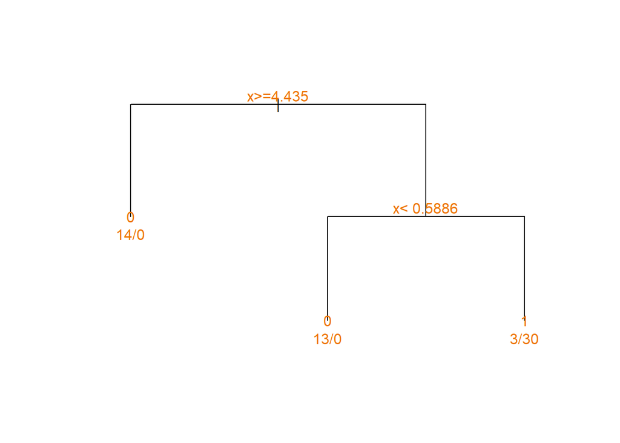

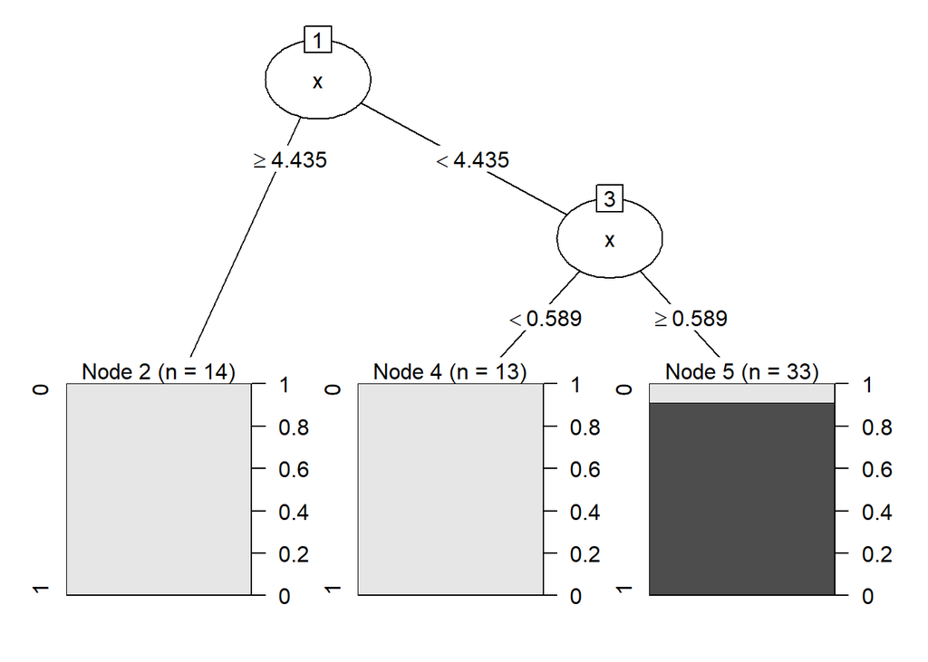

```r
tree_plot(ct)
```